# JMJPFU-SubsetPlus

# JMJPFU

### 14-Mar-2017

This notebook is to demonstrate many allied topics which were not tried out earlier. The topics which will be tried out are the following

1. Best subset selection
2. Forward selection
3. Backward selection
4. Ridge Regression & Lasso
5. PCA

Let us get started

### Initial tasks : Loading the library functions

```r
library(leaps)
library(caret)
library(ggplot2)
library(dplyr)
```

### Method 1 : Best subset selection

Let us do best subset selection and then fit the model with some of the most successful model which were create earlier.

```r
summary(subFull)
```

```
Subset selection object
Call: regsubsets.formula(label ~ ., xTrain, nvmax = 11)
11 Variables  (and intercept)
              Forced in Forced out
featDischarge     FALSE      FALSE
conSlope          FALSE      FALSE
dodMin            FALSE      FALSE
Dod50             FALSE      FALSE
Dod85             FALSE      FALSE
conDrop           FALSE      FALSE
con50             FALSE      FALSE
con80             FALSE      FALSE
voltSD            FALSE      FALSE
Dodtop            FALSE      FALSE
contop            FALSE      FALSE
1 subsets of each size up to 9
Selection Algorithm: exhaustive
         featDischarge conSlope dodMin Dod50 Dod85 Dodtop conDrop con50 con80 contop voltSD
1  ( 1 ) " "           " "      " "    " "   " "   " "    " "     " "   "*"   " "    " "
2  ( 1 ) " "           " "      " "    " "   " "   " "    " "     "*"   " "   "*"    " "
3  ( 1 ) "*"           " "      " "    " "   " "   "*"    " "     " "   "*"   " "    " "
4  ( 1 ) "*"           " "      " "    " "   " "   "*"    " "     "*"   " "   "*"    " "
5  ( 1 ) "*"           " "      " "    " "   " "   "*"    "*"     "*"   " "   "*"    " "
6  ( 1 ) "*"           " "      "*"    " "   " "   " "    "*"     " "   "*"   "*"    "*"
7  ( 1 ) "*"           " "      "*"    " "   " "   "*"    "*"     "*"   "*"   " "    "*"
8  ( 1 ) "*"           "*"      "*"    " "   " "   "*"    "*"     " "   "*"   "*"    "*"
9  ( 1 ) "*"           "*"      "*"    "*"   "*"   " "    "*"     "*"   "*"   " "    "*"
```

Let us now get some of the finer variables from the model.

```r
regSummary$cp
```

```
[1] 966.56281 696.86843 461.77953 173.43260  97.00768  50.98003  16.81051  11.03144   8.00000
```

```r
regSummary$bic
```

```
[1] -1406.693 -1644.421 -1856.988 -2127.781 -2196.024 -2234.688 -2261.766 -2260.540 -2256.570
```

Let us do some plotting of the error terms with respect to the number of variables

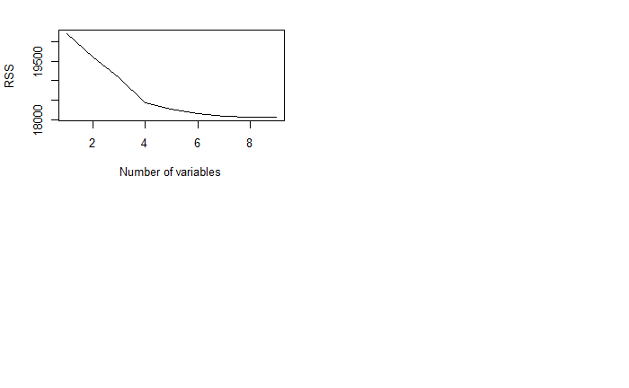

```r
par(mfrow=c(2,2))
plot(regSummary$rss,xlab="Number of variables",ylab="RSS",type="l")
plot(regSummary$adjr2,xlab="Number of variables",ylab="Adjusted R2",type = "l")
```

[output not shown]

By looking at the above figures, we can see that the RSS goes down with the number of variables . However afer 6 variables it is a constant plateau. This probably is an indicator that we can try a model with the best 6 variables

We can try modelling with the best 6 variable model after we experiment with forward selection and backward selection methods.

Let us try out the forward selection or the backward selection methods.

### Step 2 : Forward Selection of variables

# JMJPFU

### 16-Mar-2017

```r
batForward <- regsubsets(label~.,data=xTrain,nvmax = 11,method="forward")
```

```
2  linear dependencies found
```

```
Reordering variables and trying again:
```

```
number of items to replace is not a multiple of replacement length
```

```r
summary(batForward)
```

```
Subset selection object
Call: regsubsets.formula(label ~ ., data = xTrain, nvmax = 11, method = "forward")
11 Variables  (and intercept)
              Forced in Forced out
featDischarge     FALSE      FALSE
conSlope          FALSE      FALSE
dodMin            FALSE      FALSE
Dod50             FALSE      FALSE
Dod85             FALSE      FALSE
conDrop           FALSE      FALSE
con50             FALSE      FALSE
con80             FALSE      FALSE
voltSD            FALSE      FALSE
Dodtop            FALSE      FALSE
contop            FALSE      FALSE
1 subsets of each size up to 9
Selection Algorithm: forward
         featDischarge conSlope dodMin Dod50 Dod85 Dodtop conDrop con50 con80 contop voltSD
1  ( 1 ) " "           " "      " "    " "   " "   " "    " "     " "   "*"   " "    " "
2  ( 1 ) " "           " "      " "    " "   " "   " "    " "     " "   "*"   "*"    " "
3  ( 1 ) " "           " "      " "    " "   " "   "*"    " "     " "   "*"   "*"    " "
4  ( 1 ) "*"           " "      " "    " "   " "   "*"    " "     " "   "*"   "*"    " "
5  ( 1 ) "*"           " "      " "    " "   " "   "*"    "*"     " "   "*"   "*"    " "
6  ( 1 ) "*"           " "      " "    " "   " "   "*"    "*"     " "   "*"   "*"    "*"
7  ( 1 ) "*"           " "      "*"    " "   " "   "*"    "*"     " "   "*"   "*"    "*"
8  ( 1 ) "*"           "*"      "*"    " "   " "   "*"    "*"     " "   "*"   "*"    "*"
9  ( 1 ) "*"           "*"      "*"    "*"   " "   "*"    "*"     " "   "*"   "*"    "*"
```

```r
batBack <- regsubsets(label~.,data=xTrain,nvmax = 11,method="backward")
```

```
2  linear dependencies found
```

```
Reordering variables and trying again:
```

```
number of items to replace is not a multiple of replacement length
```

```r
summary(batBack)
```

```
Subset selection object
Call: regsubsets.formula(label ~ ., data = xTrain, nvmax = 11, method = "backward")
11 Variables  (and intercept)
              Forced in Forced out
featDischarge     FALSE      FALSE
conSlope          FALSE      FALSE
dodMin            FALSE      FALSE
Dod50             FALSE      FALSE
Dod85             FALSE      FALSE
conDrop           FALSE      FALSE
con50             FALSE      FALSE
con80             FALSE      FALSE
voltSD            FALSE      FALSE
Dodtop            FALSE      FALSE
contop            FALSE      FALSE
1 subsets of each size up to 9
Selection Algorithm: backward
         featDischarge conSlope dodMin Dod50 Dod85 Dodtop conDrop con50 con80 contop voltSD
1  ( 1 ) " "           " "      " "    " "   " "   " "    " "     " "   "*"   " "    " "
2  ( 1 ) " "           " "      " "    " "   " "   " "    " "     "*"   "*"   " "    " "
3  ( 1 ) " "           " "      " "    " "   " "   " "    " "     "*"   "*"   " "    "*"
4  ( 1 ) " "           " "      "*"    " "   " "   " "    " "     "*"   "*"   " "    "*"
5  ( 1 ) "*"           " "      "*"    " "   " "   " "    " "     "*"   "*"   " "    "*"
6  ( 1 ) "*"           " "      "*"    " "   " "   " "    "*"     "*"   "*"   " "    "*"
7  ( 1 ) "*"           " "      "*"    " "   "*"   " "    "*"     "*"   "*"   " "    "*"
8  ( 1 ) "*"           "*"      "*"    " "   "*"   " "    "*"     "*"   "*"   " "    "*"
9  ( 1 ) "*"           "*"      "*"    "*"   "*"   " "    "*"     "*"   "*"   " "    "*"
```